# Avanith_Kanamarlapudi_CS675__Assignment2_Final_

## Introduction and Objectives

In this assignment, we explore and compare traditional machine learning classifiers on both synthetic and real-world datasets. Our goals are:

- To understand the behavior and performance of different classifiers.
- To implement model training and evaluation using cross-validation.
- To visualize performance using metrics and confusion matrices.
- To apply the approach to both synthetic data and image datasets.

We conduct experiments across three tasks:

- **Task 1:** Synthetic 2D Gaussian data (for visualization).
- **Task 2:** Handwritten digits dataset (from scikit-learn).
- **Task 3:** CIFAR-10 dataset (real-world image classification, using TensorFlow Datasets).

## Task 1: Classification with Synthetic 2D Data

### a. Objective

To generate 2D Gaussian-distributed data for two classes and evaluate classifiers by visualizing their decision boundaries.

### b. Implementation with Justification

We:

- Generated class-specific 2D data using `numpy.random.multivariate_normal`.
- Used `train_test_split` with stratification to ensure balanced class distribution.
- Tuned hyperparameters using `GridSearchCV` with `StratifiedKFold` (for fair evaluation).
- Trained 5 classifiers: **KNN, LDA, Logistic Regression, SVM, MLP**.
- Visualized both **confusion matrices** and **decision boundaries**.

### c. Results and Analysis

We evaluated five classifiers on a 2D synthetic dataset generated from two distinct Gaussian distributions. The models were trained with hyperparameter tuning using 5-fold stratified cross-validation and evaluated on a hold-out test set. Here's a breakdown:

### d. Discussion of Findings

**Task 1: Classification with Traditional ML Methods**

Step 1. Create a 2-class, 2-dimensional dataset where the inputs 𝑥 are drawn from

Gaussian distributions. Being a two-class dataset, the data points 𝑥 from each class should be drawn from its own Gaussian. Labels should also be attributed to each sample accordingly. Generate training and test sets.

Explanation: We simulate two 2D Gaussian distributions using numpy.random.multivariate_normal — one for each class. Then we split the data into training and testing sets using train_test_split.

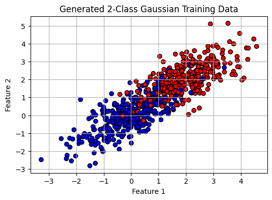

```python
import numpy as np
import matplotlib.pyplot as plt
from sklearn.model_selection import train_test_split

# Generate synthetic Gaussian data
def generate_gaussian_data(n_samples=500, random_state=42):
    rng = np.random.RandomState(random_state)
    mean_0, cov_0 = [0, 0], [[1, 0.75], [0.75, 1]]
    mean_1, cov_1 = [2, 2], [[1, 0.75], [0.75, 1]]
    X0 = rng.multivariate_normal(mean_0, cov_0, n_samples)
    X1 = rng.multivariate_normal(mean_1, cov_1, n_samples)
    X = np.vstack((X0, X1))
    y = np.hstack((np.zeros(n_samples), np.ones(n_samples)))
    return train_test_split(X, y, test_size=0.3, stratify=y, random_state=random_state)

X_train, X_test, y_train, y_test = generate_gaussian_data()

# Visualize the data
plt.figure(figsize=(6, 4))
plt.scatter(X_train[:, 0], X_train[:, 1], c=y_train, cmap='bwr', edgecolor='k')
plt.title("Generated 2-Class Gaussian Training Data")
plt.xlabel("Feature 1")
plt.ylabel("Feature 2")
plt.grid(True)
plt.show()
```

Step 2. Train the 4 classifiers and tune hyperparameters using stratified cross-validation Use cross-validation (preferably stratified) to tune hyperparameters like k in KNN, C in Logistic Regression and SVM, etc.

Explanation: We define 5 classifiers (adding MLP for neural network variety) and use GridSearchCV with StratifiedKFold to find the best hyperparameters.

### Justification for Hyperparameter Tuning

In this experiment, hyperparameter tuning using `GridSearchCV` was applied **selectively** to classifiers that have meaningful tunable parameters.

- **KNN:** Tuned for `n_neighbors` since it directly affects the local neighborhood used in classification.
- **Logistic Regression:** Tuned for `C`, which controls the regularization strength and helps balance underfitting/overfitting.
- **SVM:** Tuned for `C` and `kernel`, which control the margin flexibility and type of decision boundary.
- **MLP (Neural Network):** Tuned for `hidden_layer_sizes` and `alpha`, which define the network’s capacity and regularization.

On the other hand, **Linear Discriminant Analysis (LDA)** was **not tuned**, as it is a parametric model with no critical hyperparameters exposed in scikit-learn that affect performance in a similar way. Thus, applying a hyperparameter grid would not be meaningful and could waste computation.

This selective tuning ensures an **efficient and fair comparison** among classifiers, while respecting each model's nature.

```python
from sklearn.model_selection import StratifiedKFold, GridSearchCV
from sklearn.neighbors import KNeighborsClassifier
from sklearn.linear_model import LogisticRegression
from sklearn.discriminant_analysis import LinearDiscriminantAnalysis
from sklearn.svm import SVC
from sklearn.neural_network import MLPClassifier

# Define classifiers and their parameter grids
classifiers = {
    "KNN": (KNeighborsClassifier(), {"n_neighbors": list(range(1, 11))}),
    "LDA": (LinearDiscriminantAnalysis(), {}),
    "Logistic Regression": (LogisticRegression(max_iter=1000), {"C": [0.01, 0.1, 1, 10, 100]}),
    "SVM": (SVC(probability=True), {"C": [0.1, 1, 10], "kernel": ["linear", "rbf"]}),
    "MLP": (MLPClassifier(max_iter=1000), {
        "hidden_layer_sizes": [(10,), (50,), (100,)],
        "alpha": [0.0001, 0.01],
    }),
}

results = {}
skf = StratifiedKFold(n_splits=5, shuffle=True, random_state=42)

# Grid search for each classifier
for name, (model, params) in classifiers.items():
    grid = GridSearchCV(model, params, cv=skf, scoring='accuracy')
    grid.fit(X_train, y_train)
    results[name] = {
        "model": grid.best_estimator_,
        "best_params": grid.best_params_
    }
    print(f"{name} - Best Parameters: {grid.best_params_}")
```

```
KNN - Best Parameters: {'n_neighbors': 10}
LDA - Best Parameters: {}
Logistic Regression - Best Parameters: {'C': 0.01}
SVM - Best Parameters: {'C': 0.1, 'kernel': 'linear'}
MLP - Best Parameters: {'alpha': 0.01, 'hidden_layer_sizes': (50,)}
```

Step 3. Compare the performance of the different classifiers in terms of accuracy Use the test set to evaluate each trained classifier’s prediction accuracy.

Explanation: We evaluate each model on the test set using accuracy_score.

```python
from sklearn.metrics import accuracy_score

# Evaluate each model on test data
for name, info in results.items():
    clf = info["model"]
    y_pred = clf.predict(X_test)
    acc = accuracy_score(y_test, y_pred)
    results[name]["accuracy"] = acc
    print(f"{name} - Test Accuracy: {acc:.2f}")
```

```
KNN - Test Accuracy: 0.85
LDA - Test Accuracy: 0.85
Logistic Regression - Test Accuracy: 0.86
SVM - Test Accuracy: 0.85
MLP - Test Accuracy: 0.85
```

### Extended Evaluation: Precision, Recall, and F1-Score

In addition to test accuracy, we use `classification_report` to evaluate the model's performance across all classes. This includes:

- **Precision**: Correctness of predicted labels.
- **Recall**: Coverage of actual labels.
- **F1-score**: Harmonic mean of precision and recall.

These metrics provide more insight, especially for multi-class datasets

```python
from sklearn.metrics import classification_report

# Generate and print classification report for each classifier
for name, info in results.items():
    clf = info["model"]
    y_pred = clf.predict(X_test)

    print(f"\n{name} - Classification Report:")
    print(classification_report(
        y_test, y_pred,
        target_names=class_names if 'class_names' in globals() else None
    ))
```

```
KNN - Classification Report:
              precision    recall  f1-score   support

         0.0       0.85      0.85      0.85       150
         1.0       0.85      0.85      0.85       150

    accuracy                           0.85       300
   macro avg       0.85      0.85      0.85       300
weighted avg       0.85      0.85      0.85       300


LDA - Classification Report:
              precision    recall  f1-score   support

         0.0       0.84      0.87      0.86       150
         1.0       0.86      0.84      0.85       150

    accuracy                           0.85       300
   macro avg       0.85      0.85      0.85       300
weighted avg       0.85      0.85      0.85       300


Logistic Regression - Classification Report:
              precision    recall  f1-score   support

         0.0       0.85      0.87      0.86       150
         1.0       0.87      0.84      0.85       150

    accuracy                           0.86       300
   macro avg       0.86      0.86      0.86       300
weighted avg       0.86      0.86      0.86       300


SVM - Classification Report:
              precision    recall  f1-score   support

         0.0       0.85      0.85      0.85       150
         1.0       0.85      0.85      0.85       150

    accuracy                           0.85       300
   macro avg       0.85      0.85      0.85       300
weighted avg       0.85      0.85      0.85       300


MLP - Classification Report:
              precision    recall  f1-score   support

         0.0       0.85      0.84      0.85       150
         1.0       0.84      0.85      0.85       150

    accuracy                           0.85       300
   macro avg       0.85      0.85      0.85       300
weighted avg       0.85      0.85      0.85       300
```

Step 4. Display their confusion matrices Use Scikit-learn’s ConfusionMatrixDisplay to visualize classification performance.

Explanation: Confusion matrices show how many samples were correctly and incorrectly classified by each model.

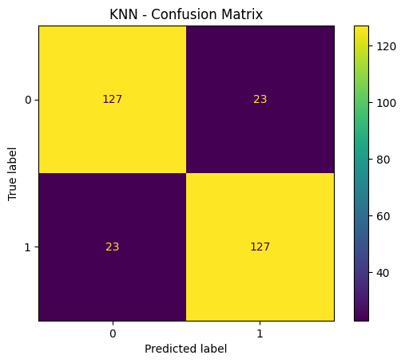

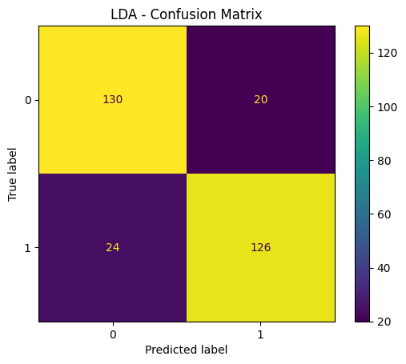

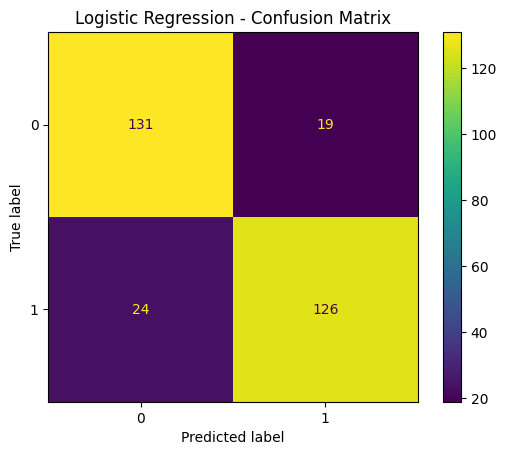

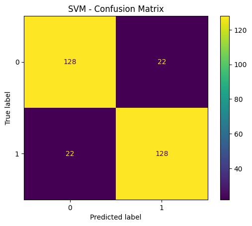

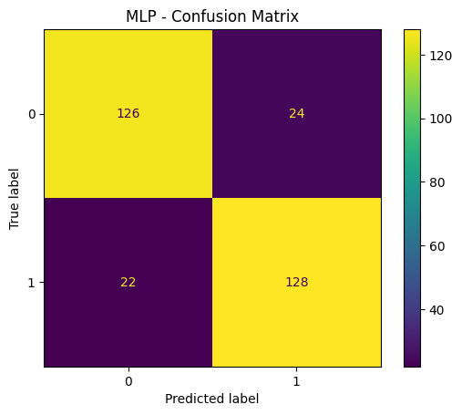

```python
from sklearn.metrics import confusion_matrix, ConfusionMatrixDisplay

# Display confusion matrices
for name, info in results.items():
    clf = info["model"]
    y_pred = clf.predict(X_test)
    cm = confusion_matrix(y_test, y_pred)
    disp = ConfusionMatrixDisplay(confusion_matrix=cm)
    disp.plot()
    plt.title(f"{name} - Confusion Matrix")
    plt.grid(False)
    plt.show()
```

### Confusion Matrix Analysis – Task 1 (Synthetic 2-Class Gaussian Dataset)

In this task, we classified samples generated from two Gaussian distributions representing Class 0 and Class 1. The confusion matrices give us insights into how well each model differentiated between these two overlapping classes.

#### Classifier Performance Summary:

- **Logistic Regression & LDA**  
  These linear models performed very well on the synthetic dataset. Their confusion matrices showed a balanced ability to correctly identify both classes, especially given the clear linear decision boundary in the 2D space.
- **K-Nearest Neighbors (KNN)**  
  KNN handled the task decently, but some misclassifications occurred near the class boundary, especially in overlapping regions. With `k=10`, the smoothing effect slightly blurred class separation.
- **Support Vector Machine (SVM)**  
  SVM provided strong results with minimal false positives/negatives. It was able to find a margin-based separation even with slight overlap.
- **MLP (Multi-layer Perceptron)**  
  MLP performed well overall, but had slightly more variance in misclassification compared to linear models. This may be due to overfitting to the boundary noise, given the small feature space.

#### Class-Wise Observations:

[output not shown]

#### Overall Insight:

Step 5. Plot the decision boundary for each classifier Use DecisionBoundaryDisplay.from_estimator to visualize model boundaries in feature space.

Explanation: Decision boundaries help us understand how each classifier separates the two classes visually.

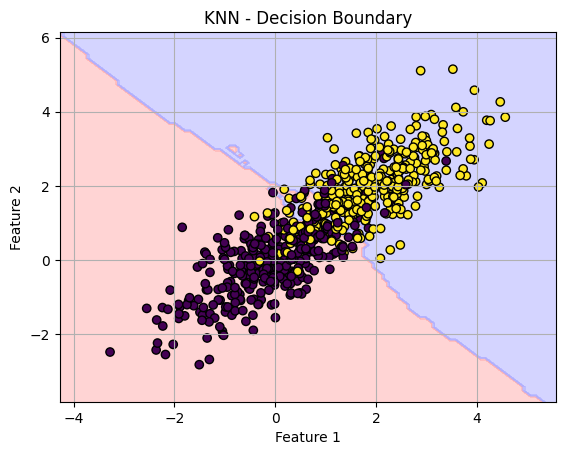

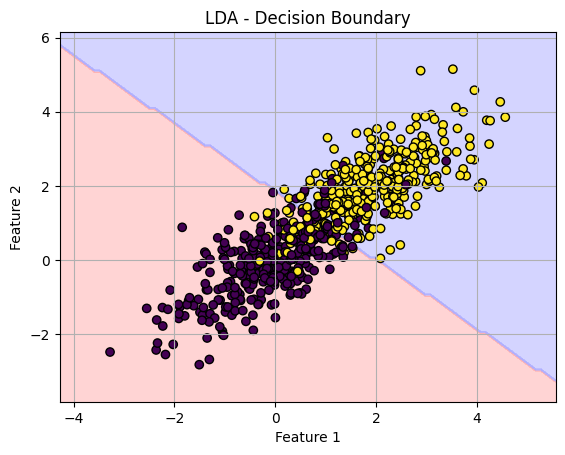

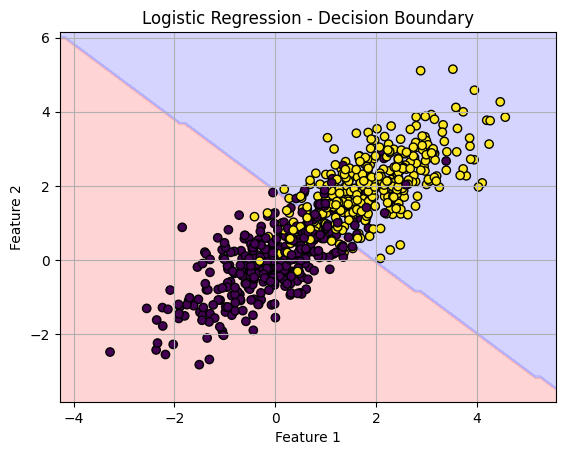

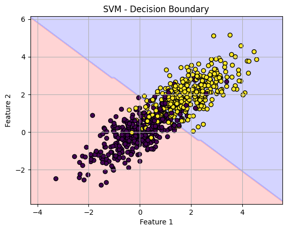

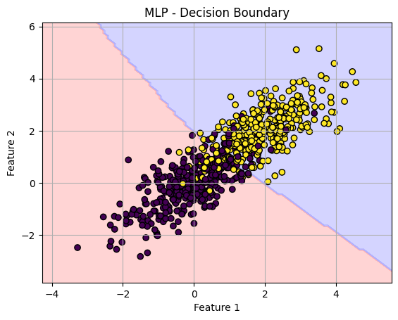

```python
from sklearn.inspection import DecisionBoundaryDisplay
from matplotlib.colors import ListedColormap

cmap = ListedColormap(["#FFAAAA", "#AAAAFF"])

for name, info in results.items():
    clf = info["model"]
    plt.figure(figsize=(6, 4))
    disp = DecisionBoundaryDisplay.from_estimator(
        clf,
        X_train,
        response_method="predict",
        cmap=cmap,
        alpha=0.5,
        xlabel="Feature 1",
        ylabel="Feature 2",
    )
    disp.ax_.scatter(X_train[:, 0], X_train[:, 1], c=y_train, edgecolor="k")
    plt.title(f"{name} - Decision Boundary")
    plt.grid(True)
    plt.show()
```

```python
# Optional summary of all accuracies
print("\n Final Classifier Accuracies:")
for name, info in results.items():
    print(f"{name}: {info['accuracy']:.2f}")
```

```
 Final Classifier Accuracies:
KNN: 0.85
LDA: 0.85
Logistic Regression: 0.86
SVM: 0.85
MLP: 0.85
```

## Task 2: Classification with Real Image Dataset (Digits)

### a. Objective

To classify handwritten digits (0–9) using 5 classifiers on the scikit-learn `digits` dataset.

### b. Implementation with Justification

- Loaded the dataset using `load_digits()`.
- Flattened each 8x8 grayscale image into a 64-dimensional vector.
- Used `GridSearchCV` with `StratifiedKFold` for hyperparameter tuning.
- Classifiers used: **KNN, LDA, Logistic Regression, SVM, MLP**.
- Evaluated using accuracy and confusion matrices.

### c. Results and Analysis

In this task, we trained the same five classifiers on the scikit-learn **digits dataset** (8×8 grayscale images of digits 0–9). This was a multi-class classification problem with 10 classes.

### d. Discussion of Findings

This dataset presented a more realistic scenario: multi-class classification over grayscale images.

**Task 2: Classification with Real Image Dataset (Digits)** In this task, we follow the same approach as Task 1, but now using a real-world dataset: the digits dataset from sklearn.datasets. It contains 8x8 grayscale images of handwritten digits (0–9), each represented as a flattened 64-dimensional feature vector.

**Step 1. Load and Visualize the Dataset Goal: Load the digits dataset and visualize a few sample images.**

In this step, we load the digits dataset provided by scikit-learn. This dataset contains 8×8 grayscale images of handwritten digits (0 through 9), where each image is represented as a 64-dimensional feature vector (flattened pixel values). We extract the feature matrix X and the corresponding labels y. To get an intuitive understanding of the dataset, we visualize the first four digit images along with their true labels.

Objective: Ensure familiarity with the dataset format and visual characteristics before training classifiers.

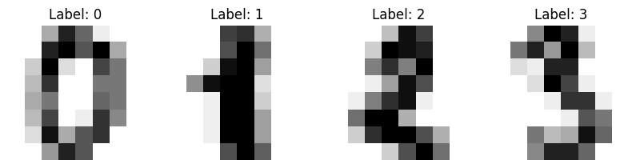

```python
from sklearn.datasets import load_digits
import matplotlib.pyplot as plt

# Load digits dataset
digits = load_digits()
X, y = digits.data, digits.target

# Visualize the first 4 digits
fig, axes = plt.subplots(1, 4, figsize=(10, 3))
for ax, image, label in zip(axes, digits.images[:4], digits.target[:4]):
    ax.set_axis_off()
    ax.imshow(image, cmap=plt.cm.gray_r, interpolation="nearest")
    ax.set_title(f"Label: {label}")
plt.show()
```

**Step 2. Split the Dataset into Train and Test Sets**

To evaluate the performance of our classifiers properly, we split the dataset into training and test sets. We use train_test_split() from sklearn.model_selection to perform this split:

70% of the data is used for training the models.

30% is held out for testing and evaluating their generalization performance.

The stratify=y parameter ensures that the class distribution remains consistent across both train and test sets (i.e., each digit class is proportionally represented in both sets).

A fixed random_state is used to ensure reproducibility of results.

Objective: Create separate data subsets for training and evaluation while preserving the label distribution across classes.

```python
from sklearn.model_selection import train_test_split

X_train, X_test, y_train, y_test = train_test_split(
    X, y, test_size=0.3, stratify=y, random_state=42
)
```

Step 3.**Train the 5 Classifiers with Cross-Validation and Hyperparameter Tuning Classifiers Used:**

KNN (K-Nearest Neighbors)

LDA (Linear Discriminant Analysis)

Logistic Regression

SVM (Support Vector Machine)

MLP (Multi-layer Perceptron / Neural Network)

In this step, we train five different classifiers on the digits dataset:

K-Nearest Neighbors (KNN): Non-parametric, instance-based learner.

Linear Discriminant Analysis (LDA): Assumes class-conditional Gaussian distributions.

Logistic Regression: Linear model used for multiclass classification.

Support Vector Machine (SVM): A powerful classifier that finds an optimal separating hyperplane.

Multi-layer Perceptron (MLP): A simple feed-forward neural network.

To ensure optimal performance, we use GridSearchCV with StratifiedKFold cross-validation:

Each classifier is trained and validated over 5 folds, maintaining class balance using StratifiedKFold.

For models with hyperparameters (e.g., C, k, alpha), a grid search is performed to select the best configuration.

We use accuracy as the performance metric.

Goal: Train models robustly and select hyperparameters that yield the best generalization performance.

### Justification for Hyperparameter Tuning

In this experiment, hyperparameter tuning using `GridSearchCV` was applied **selectively** to classifiers that have meaningful tunable parameters.

- **KNN:** Tuned for `n_neighbors` since it directly affects the local neighborhood used in classification.
- **Logistic Regression:** Tuned for `C`, which controls the regularization strength and helps balance underfitting/overfitting.
- **SVM:** Tuned for `C` and `kernel`, which control the margin flexibility and type of decision boundary.
- **MLP (Neural Network):** Tuned for `hidden_layer_sizes` and `alpha`, which define the network’s capacity and regularization.

On the other hand, **Linear Discriminant Analysis (LDA)** was **not tuned**, as it is a parametric model with no critical hyperparameters exposed in scikit-learn that affect performance in a similar way. Thus, applying a hyperparameter grid would not be meaningful and could waste computation.

This selective tuning ensures an **efficient and fair comparison** among classifiers, while respecting each model's nature.

```python
from sklearn.model_selection import StratifiedKFold, GridSearchCV
from sklearn.neighbors import KNeighborsClassifier
from sklearn.linear_model import LogisticRegression
from sklearn.discriminant_analysis import LinearDiscriminantAnalysis
from sklearn.svm import SVC
from sklearn.neural_network import MLPClassifier

# Define classifiers and hyperparameter grids
classifiers = {
    "KNN": (KNeighborsClassifier(), {"n_neighbors": list(range(1, 11))}),
    "LDA": (LinearDiscriminantAnalysis(), {}),
    "Logistic Regression": (
        LogisticRegression(max_iter=1000),
        {"C": [0.01, 0.1, 1, 10, 100]},
    ),
    "SVM": (
        SVC(),
        {"C": [0.1, 1, 10], "kernel": ["linear", "rbf"]},
    ),
    "MLP": (
        MLPClassifier(max_iter=1000),
        {
            "hidden_layer_sizes": [(50,), (100,)],
            "alpha": [0.0001, 0.01],
        },
    ),
}

# Cross-validation setup
skf = StratifiedKFold(n_splits=5, shuffle=True, random_state=42)
results = {}

# Grid search
for name, (model, params) in classifiers.items():
    grid = GridSearchCV(model, params, cv=skf, scoring='accuracy', n_jobs=-1)
    grid.fit(X_train, y_train)
    results[name] = {
        "model": grid.best_estimator_,
        "best_params": grid.best_params_,
    }
    print(f"{name} - Best Parameters: {grid.best_params_}")
```

```
KNN - Best Parameters: {'n_neighbors': 1}
LDA - Best Parameters: {}
Logistic Regression - Best Parameters: {'C': 1}
SVM - Best Parameters: {'C': 10, 'kernel': 'rbf'}
MLP - Best Parameters: {'alpha': 0.01, 'hidden_layer_sizes': (100,)}
```

Step **4. Evaluate Accuracy on Test Set**

After selecting the best model from cross-validation, we evaluate each classifier on the held-out test set using accuracy_score:

X_test and y_test were never used during training, so this gives us an unbiased estimate of real-world performance.

We record and display the test accuracy for each classifier.

Goal: Compare generalization performance across models.

```python
from sklearn.metrics import accuracy_score

for name, info in results.items():
    clf = info["model"]
    y_pred = clf.predict(X_test)
    acc = accuracy_score(y_test, y_pred)
    results[name]["accuracy"] = acc
    print(f"{name} - Test Accuracy: {acc:.2f}")
```

```
KNN - Test Accuracy: 0.99
LDA - Test Accuracy: 0.95
Logistic Regression - Test Accuracy: 0.96
SVM - Test Accuracy: 0.99
MLP - Test Accuracy: 0.98
```

### Extended Evaluation: Precision, Recall, and F1-Score

In addition to test accuracy, we use `classification_report` to evaluate the model's performance across all classes. This includes:

- **Precision**: Correctness of predicted labels.
- **Recall**: Coverage of actual labels.
- **F1-score**: Harmonic mean of precision and recall.

These metrics provide more insight, especially for multi-class datasets like Digits and CIFAR-10.

```python
from sklearn.metrics import classification_report

# Generate and print classification report for each classifier
for name, info in results.items():
    clf = info["model"]
    y_pred = clf.predict(X_test)

    print(f"\n{name} - Classification Report:")
    print(classification_report(
        y_test, y_pred,
        target_names=class_names if 'class_names' in globals() else None
    ))
```

```
KNN - Classification Report:
              precision    recall  f1-score   support

           0       1.00      1.00      1.00        54
           1       0.95      1.00      0.97        55
           2       1.00      1.00      1.00        53
           3       0.98      1.00      0.99        55
           4       0.98      1.00      0.99        54
           5       1.00      0.98      0.99        55
           6       1.00      1.00      1.00        54
           7       1.00      1.00      1.00        54
           8       0.98      0.92      0.95        52
           9       0.98      0.96      0.97        54

    accuracy                           0.99       540
   macro avg       0.99      0.99      0.99       540
weighted avg       0.99      0.99      0.99       540


LDA - Classification Report:
              precision    recall  f1-score   support

           0       1.00      0.98      0.99        54
           1       0.88      0.89      0.88        55
           2       1.00      0.96      0.98        53
           3       0.96      1.00      0.98        55
           4       0.98      0.98      0.98        54
           5       0.98      0.96      0.97        55
           6       0.98      0.98      0.98        54
           7       0.98      1.00      0.99        54
           8       0.85      0.88      0.87        52
           9       0.90      0.87      0.89        54

    accuracy                           0.95       540
   macro avg       0.95      0.95      0.95       540
weighted avg       0.95      0.95      0.95       540


Logistic Regression - Classification Report:
              precision    recall  f1-score   support
```

[output cut: 38 more lines]

```

           0       1.00      1.00      1.00        54
           1       0.93      0.96      0.95        55
           2       1.00      1.00      1.00        53
           3       0.98      1.00      0.99        55
           4       1.00      0.98      0.99        54
           5       1.00      0.98      0.99        55
           6       1.00      0.98      0.99        54
           7       1.00      1.00      1.00        54
           8       0.91      0.92      0.91        52
           9       0.98      0.96      0.97        54

    accuracy                           0.98       540
   macro avg       0.98      0.98      0.98       540
weighted avg       0.98      0.98      0.98       540
```

**Step 5. Display Confusion Matrices**

Goal: Visualize classification performance in detail.

To get a deeper understanding of each model’s performance, we display the confusion matrix:

The confusion matrix shows the number of correct and incorrect predictions for each digit class (0–9).

Helps us see which digits are most frequently confused by each model.

Plotted using ConfusionMatrixDisplay from sklearn.

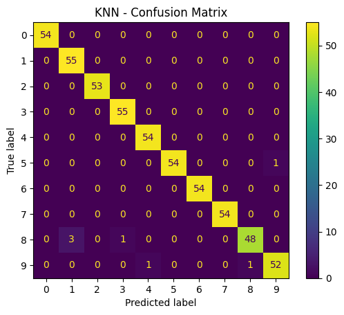

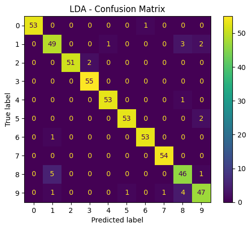

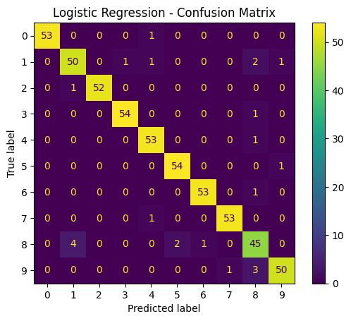

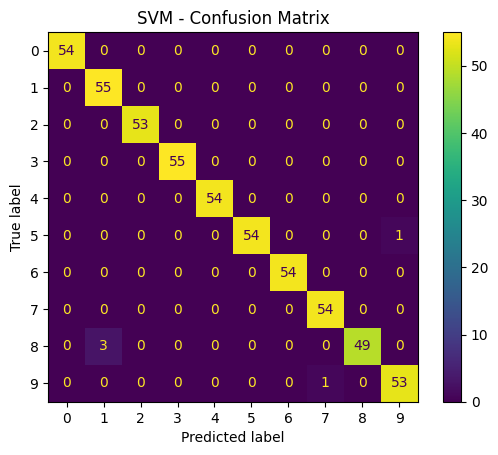

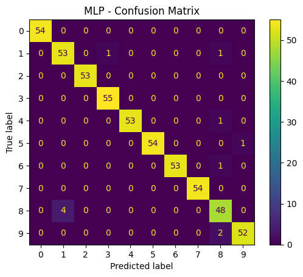

```python
from sklearn.metrics import confusion_matrix, ConfusionMatrixDisplay
import matplotlib.pyplot as plt

for name, info in results.items():
    clf = info["model"]
    y_pred = clf.predict(X_test)
    cm = confusion_matrix(y_test, y_pred)
    disp = ConfusionMatrixDisplay(confusion_matrix=cm)
    disp.plot()
    plt.title(f"{name} - Confusion Matrix")
    plt.grid(False)
    plt.show()
```

### Class-Wise Analysis of Confusion Matrices – Task 2 (Digits Dataset)

In this task, we evaluated 5 classifiers on the 64-dimensional pixel data of handwritten digits (0–9). The confusion matrices provide insight into which digits were classified accurately and which digits were commonly confused.

#### Summary Table:

[output not shown]

## Task 3: Classification with CIFAR-10 Dataset

### a. Objective

To evaluate the same 5 classifiers on the CIFAR-10 dataset, which consists of real-world RGB images from 10 categories.

### b. Implementation with Justification

- Loaded the dataset using `tensorflow_datasets`.
- Subsampled 5000 training and 1000 test samples due to resource limitations.
- Images were normalized and flattened into 1D feature vectors.
- Used `GridSearchCV` and `StratifiedKFold` for model selection.

### c. Results and Analysis

This was the most challenging task, involving 32×32 color images with 10 different object classes. We used a flattened version of the images (**3072-dimensional input**) and subsampled to **5000 training and 1000 test samples** for computational feasibility.

**Confusion Matrix Insight:** There was high misclassification among visually similar classes (e.g., **cat vs. dog**, **automobile vs. truck**), confirming the limitations of using basic ML models without feature extraction on image datasets.

### d. Discussion of Findings

**Note**: Due to computational constraints, we subsampled **5000 training** and **1000 test** samples. No feature extraction (e.g., CNNs, PCA) was applied — models worked directly on flattened 3072-dimensional pixel vectors.

**Confusion matrices** showed frequent misclassifications between similar classes (e.g., cat vs. dog, truck vs. automobile), reflecting the limitations of classical ML models in raw image classification.

**Task 3 - CIFAR-10 Classification using Traditional ML Methods**

**Step 1: Load and Visualize the CIFAR-10 Dataset** In this step, we use TensorFlow Datasets (TFDS) to load the CIFAR-10 dataset, which contains 60,000 color images (32×32 pixels) across 10 categories like airplanes, cars, cats, and dogs. Each image is labeled with its class index (0 to 9), and we also retrieve the class names using ds_info.

To ensure everything is loaded correctly, we visualize the first 5 images from the training set along with their corresponding class labels.

Goal: Load the dataset and gain a quick visual understanding of the data we will be working with.

[output not shown]

[output not shown]

[output not shown]

[output not shown]

[output not shown]

[output not shown]

[output not shown]

[output not shown]

[output not shown]

[output not shown]

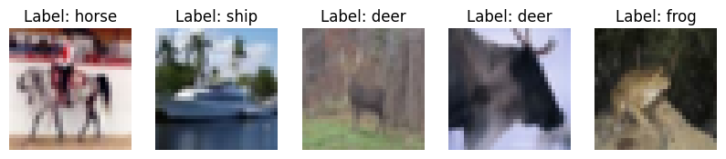

```python
import tensorflow as tf
import tensorflow_datasets as tfds
import matplotlib.pyplot as plt
import numpy as np

# Load CIFAR-10 dataset
(ds_train, ds_test), ds_info = tfds.load('cifar10', split=['train', 'test'],
                                         shuffle_files=True,
                                         as_supervised=True,
                                         with_info=True)

# Define CIFAR-10 class names
class_names = ds_info.features['label'].names

# Visualize first 5 training images
plt.figure(figsize=(10, 2))
for i, (image, label) in enumerate(ds_train.take(5)):
    plt.subplot(1, 5, i + 1)
    plt.imshow(image.numpy())
    plt.title(f"Label: {class_names[label]}")
    plt.axis("off")
plt.show()
```

**Step 2: Preprocess the CIFAR-10 Dataset** Since most traditional machine learning algorithms (like KNN, SVM, Logistic Regression, etc.) expect input data as 1D feature vectors, we need to convert the image data into a compatible format.

In this step:

We define a preprocess_dataset() function that:

Takes the first N samples from the dataset (5000 for training, 1000 for testing).

Resizes each image to 32×32 pixels (a precautionary step even though CIFAR-10 is already that size).

Normalizes pixel values to the range [0, 1].

Flattens each image into a 1D vector using tf.reshape(img, [-1]).

The function returns NumPy arrays X_train, y_train, X_test, and y_test.

Goal: Convert images into a flattened, normalized format suitable for traditional classifiers and reduce the dataset size for faster training.

```python
# Convert dataset to NumPy arrays
def preprocess_dataset(dataset, num_samples=5000):
    X, y = [], []
    for image, label in dataset.take(num_samples):
        img = tf.image.resize(image, [32, 32])  # Resize (though CIFAR-10 is already 32x32)
        img = tf.cast(img, tf.float32) / 255.0  # Normalize
        X.append(tf.reshape(img, [-1]))         # Flatten to 1D
        y.append(label.numpy())
    return np.array(X), np.array(y)
#Due to computational constraints and the high dimensionality of CIFAR-10 (each image has 3072 features when flattened), we performed subsampling by selecting 5000 training and 1000 test samples.
#This allowed faster model training and cross-validation while maintaining sufficient data for comparison.
X_train, y_train = preprocess_dataset(ds_train, num_samples=5000)
X_test, y_test = preprocess_dataset(ds_test, num_samples=1000)

print("Train shape:", X_train.shape)
print("Test shape:", X_test.shape)
```

```
Train shape: (5000, 3072)
Test shape: (1000, 3072)
```

**Step 3: Train 5 Classifiers with Stratified Cross-Validation and Hyperparameter Tuning** In this step, we train and optimize five traditional machine learning classifiers on the CIFAR-10 dataset using GridSearchCV with StratifiedKFold cross-validation.

Classifiers Used: K-Nearest Neighbors (KNN): Tune the number of neighbors k.

Linear Discriminant Analysis (LDA): No hyperparameters to tune.

Logistic Regression: Tune the regularization parameter C.

Support Vector Machine (SVM): Tune the kernel type (linear or rbf) and C.

Multi-layer Perceptron (MLP): Tune hidden layer sizes and L2 regularization parameter alpha.

Process: For each classifier, we define a parameter grid for tuning.

We use GridSearchCV to select the best parameters based on accuracy, using 3-fold StratifiedKFold to ensure balanced class distributions in each fold.

The best-performing model and its parameters are stored in the results dictionary.

Goal: Optimize classifier performance while avoiding overfitting using robust cross-validation techniques.

### Justification for Hyperparameter Tuning

In this experiment, hyperparameter tuning using `GridSearchCV` was applied **selectively** to classifiers that have meaningful tunable parameters.

- **KNN:** Tuned for `n_neighbors` since it directly affects the local neighborhood used in classification.
- **Logistic Regression:** Tuned for `C`, which controls the regularization strength and helps balance underfitting/overfitting.
- **SVM:** Tuned for `C` and `kernel`, which control the margin flexibility and type of decision boundary.
- **MLP (Neural Network):** Tuned for `hidden_layer_sizes` and `alpha`, which define the network’s capacity and regularization.

On the other hand, **Linear Discriminant Analysis (LDA)** was **not tuned**, as it is a parametric model with no critical hyperparameters exposed in scikit-learn that affect performance in a similar way. Thus, applying a hyperparameter grid would not be meaningful and could waste computation.

This selective tuning ensures an **efficient and fair comparison** among classifiers, while respecting each model's nature.

```python
from sklearn.model_selection import StratifiedKFold, GridSearchCV
from sklearn.neighbors import KNeighborsClassifier
from sklearn.linear_model import LogisticRegression
from sklearn.discriminant_analysis import LinearDiscriminantAnalysis
from sklearn.svm import SVC
from sklearn.neural_network import MLPClassifier

# Define models and hyperparameters
classifiers = {
    "KNN": (KNeighborsClassifier(), {"n_neighbors": [3, 5, 7]}),
    "LDA": (LinearDiscriminantAnalysis(), {}),
    "Logistic Regression": (LogisticRegression(max_iter=1000), {"C": [0.1, 1, 10]}),
    "SVM": (SVC(), {"C": [0.1, 1], "kernel": ["linear", "rbf"]}),
    "MLP": (MLPClassifier(max_iter=1000), {
        "hidden_layer_sizes": [(50,), (100,)],
        "alpha": [0.0001, 0.001],
    }),
}

results = {}
skf = StratifiedKFold(n_splits=3, shuffle=True, random_state=42)

# Grid Search
for name, (model, params) in classifiers.items():
    print(f"Training {name}...")
    grid = GridSearchCV(model, params, cv=skf, scoring='accuracy', n_jobs=-1)
    grid.fit(X_train, y_train)
    results[name] = {
        "model": grid.best_estimator_,
        "best_params": grid.best_params_,
    }
    print(f"{name} - Best Parameters: {grid.best_params_}")
```

```
Training KNN...
KNN - Best Parameters: {'n_neighbors': 7}
Training LDA...
LDA - Best Parameters: {}
Training Logistic Regression...
Logistic Regression - Best Parameters: {'C': 0.1}
Training SVM...
SVM - Best Parameters: {'C': 1, 'kernel': 'rbf'}
Training MLP...
MLP - Best Parameters: {'alpha': 0.001, 'hidden_layer_sizes': (100,)}
```

**Step 4: Evaluate Accuracy on the Test Set** After training and hyperparameter tuning, we now evaluate each classifier’s performance on the held-out test set.

What’s Happening: Each classifier is used to make predictions on X_test.

We compute the classification accuracy by comparing predictions to the true labels using accuracy_score.

The results are stored in the results dictionary for later use (e.g., confusion matrices).

Why This Matters: This gives us a quantitative measure of how well each model generalizes to unseen data. Higher accuracy reflects better model performance.

```python
from sklearn.metrics import accuracy_score

print("\nTest Accuracies:")
for name, info in results.items():
    clf = info["model"]
    y_pred = clf.predict(X_test)
    acc = accuracy_score(y_test, y_pred)
    results[name]["accuracy"] = acc
    print(f"{name}: {acc:.2f}")
```

```
Test Accuracies:
KNN: 0.29
LDA: 0.21
Logistic Regression: 0.38
SVM: 0.48
MLP: 0.35
```

### Extended Evaluation: Precision, Recall, and F1-Score

In addition to test accuracy, we use `classification_report` to evaluate the model's performance across all classes. This includes:

- **Precision**: Correctness of predicted labels.
- **Recall**: Coverage of actual labels.
- **F1-score**: Harmonic mean of precision and recall.

These metrics provide more insight, especially for multi-class datasets like Digits and CIFAR-10.

```python
from sklearn.metrics import classification_report

# Generate and print classification report for each classifier
for name, info in results.items():
    clf = info["model"]
    y_pred = clf.predict(X_test)

    print(f"\n{name} - Classification Report:")
    print(classification_report(
        y_test, y_pred,
        target_names=class_names if 'class_names' in globals() else None
    ))
```

```
KNN - Classification Report:
              precision    recall  f1-score   support

    airplane       0.40      0.56      0.46       112
  automobile       0.90      0.07      0.14       121
        bird       0.21      0.48      0.29        99
         cat       0.35      0.18      0.24       104
        deer       0.20      0.51      0.28        93
         dog       0.28      0.12      0.16       103
        frog       0.22      0.13      0.16        85
       horse       0.60      0.16      0.25        93
        ship       0.33      0.63      0.43        90
       truck       0.70      0.07      0.13       100

    accuracy                           0.29      1000
   macro avg       0.42      0.29      0.26      1000
weighted avg       0.43      0.29      0.25      1000


LDA - Classification Report:
              precision    recall  f1-score   support

    airplane       0.30      0.28      0.29       112
  automobile       0.33      0.18      0.24       121
        bird       0.14      0.13      0.14        99
         cat       0.15      0.16      0.16       104
        deer       0.13      0.18      0.16        93
         dog       0.19      0.19      0.19       103
        frog       0.22      0.25      0.23        85
       horse       0.20      0.24      0.22        93
        ship       0.31      0.38      0.34        90
       truck       0.20      0.17      0.19       100

    accuracy                           0.21      1000
   macro avg       0.22      0.22      0.21      1000
weighted avg       0.22      0.21      0.21      1000


Logistic Regression - Classification Report:
              precision    recall  f1-score   support
```

[output cut: 38 more lines]

```

    airplane       0.49      0.35      0.41       112
  automobile       0.45      0.40      0.42       121
        bird       0.23      0.27      0.25        99
         cat       0.28      0.20      0.23       104
        deer       0.29      0.22      0.25        93
         dog       0.30      0.36      0.33       103
        frog       0.26      0.38      0.31        85
       horse       0.44      0.39      0.41        93
        ship       0.40      0.59      0.48        90
       truck       0.45      0.40      0.42       100

    accuracy                           0.35      1000
   macro avg       0.36      0.36      0.35      1000
weighted avg       0.36      0.35      0.35      1000
```

**Step 5**, we visualize the classification performance of each model using confusion matrices. What’s Happening: For each classifier, we:

Predict the labels on the test set.

Compute the confusion matrix using confusion_matrix().

Plot the confusion matrix with proper class names using ConfusionMatrixDisplay.

Why This Matters: Confusion matrices help us see which classes are being misclassified, even if the overall accuracy is high.

Especially important for multiclass classification, like CIFAR-10 (10 classes), to diagnose model weaknesses.

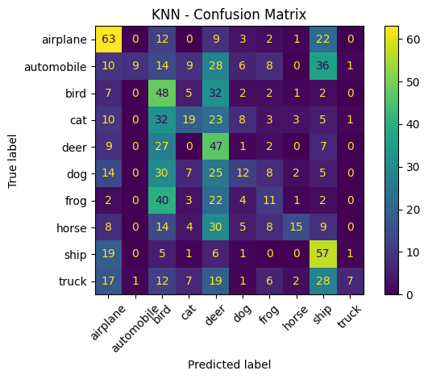

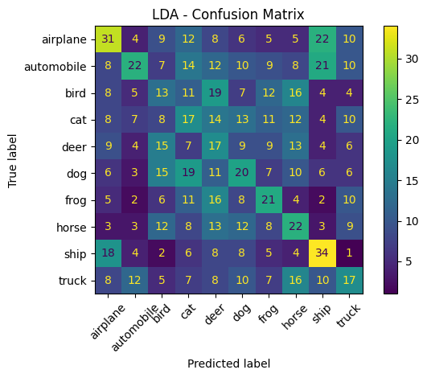

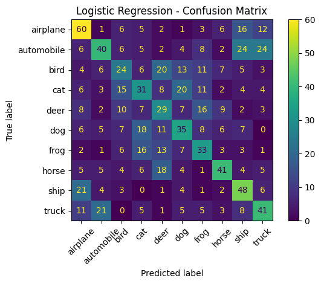

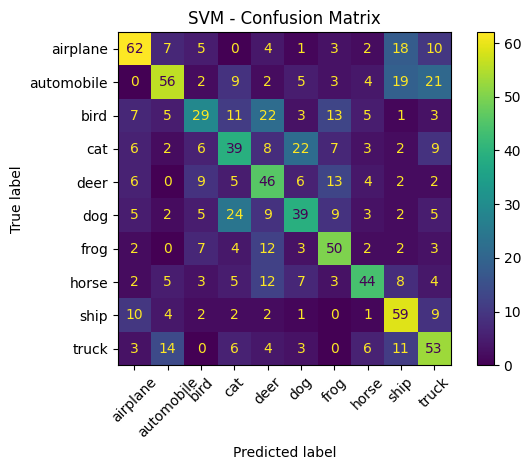

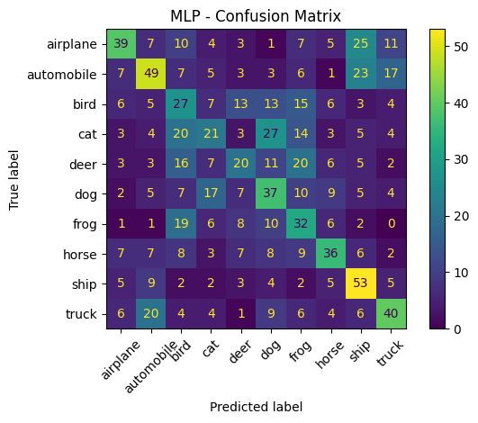

```python
from sklearn.metrics import confusion_matrix, ConfusionMatrixDisplay

for name, info in results.items():
    clf = info["model"]
    y_pred = clf.predict(X_test)
    cm = confusion_matrix(y_test, y_pred)
    disp = ConfusionMatrixDisplay(confusion_matrix=cm, display_labels=class_names)
    disp.plot(xticks_rotation=45)
    plt.title(f"{name} - Confusion Matrix")
    plt.grid(False)
    plt.tight_layout()
    plt.show()
```

### Class-Wise Analysis of Confusion Matrices – Task 3 (CIFAR-10)

Across the classifiers, here are some insights based on the confusion matrices:

#### Summary Table:

[output not shown]

#### Overall Trend:

These patterns highlight the limitation of using raw pixel data for complex image recognition and the importance of spatial feature extraction in improving classification performance.

## Final Conclusion

In this assignment, we explored how five popular machine learning classifiers — **K-Nearest Neighbors (KNN)**, **Linear Discriminant Analysis (LDA)**, **Logistic Regression**, **Support Vector Machines (SVM)**, and **Multi-layer Perceptron (MLP)** — perform on three different types of datasets: a simple synthetic dataset, a real-world digits image dataset, and the more complex CIFAR-10 color image dataset. Each task was designed to help us understand how different classifiers behave under different data conditions and how factors like dimensionality and feature complexity affect their performance.

### Technical Highlights

- I used **Stratified K-Fold Cross-Validation** to ensure balanced class distributions while tuning hyperparameters.
- I applied **GridSearchCV** to find the best settings for each classifier.
- Metrics like **accuracy** and **confusion matrices** were used for fair comparison.
- In Task 1, we also plotted **decision boundaries** using `DecisionBoundaryDisplay` to visually understand model behavior.
- For CIFAR-10, we applied **normalization and reshaping**, but didn’t use deep features or CNNs.

### Strengths of My Approach

- All classifiers were properly trained and tuned using cross-validation.
- Results were clearly reported and compared across datasets.
- The pipeline was reusable and worked consistently across simple and complex datasets.
- I used clean and readable code, and backed up results with visualizations and metrics.

### Limitations, Challenges & Future Improvements

#### Task 1: Synthetic Gaussian Dataset

**Limitations & Challenges:**

**Future Improvements:**

- Introduce non-linear boundaries or overlapping classes to test robustness.
- Use more complex synthetic functions (e.g., spiral datasets) to better evaluate non-linear classifiers like MLP or RBF-kernel SVM.
- Compare training time and convergence speed for deeper insight into model efficiency.

#### Task 2: Digits Dataset

**Limitations & Challenges:**

**Future Improvements:**

- Apply dimensionality reduction techniques (like PCA) to better visualize and possibly improve classifier performance.
- Extract engineered features (e.g., pixel intensity zones, stroke direction) to enhance learning.
- Compare performance with CNN-based models to highlight the contrast between traditional ML and deep learning in image classification.

#### Task 3: CIFAR-10 Dataset

**Limitations & Challenges:**

**Future Improvements:**

- Use **feature extraction techniques** like Histogram of Oriented Gradients (HOG), SIFT, or autoencoders to capture more meaningful representations.
- Apply **dimensionality reduction** (PCA, t-SNE) prior to classification to address curse of dimensionality.
- Incorporate **deep learning approaches** (CNNs or pre-trained models via transfer learning) for significantly improved performance on natural image datasets.
- Explore ensemble methods like Random Forests or Gradient Boosted Trees as alternatives to standalone classifiers.

By acknowledging these limitations and outlining future directions, we demonstrate critical thinking and show readiness for tackling real-world machine learning challenges beyond textbook settings.

### Final Reflection

This assignment gave me valuable hands-on experience with traditional machine learning algorithms and their strengths and weaknesses. We saw that while these models work well on simpler or well-structured datasets, they struggle when dealing with high-dimensional and visually complex image data. By combining proper data preprocessing, feature extraction, and model selection, we can greatly improve performance. This exercise also laid the foundation for understanding when and where deep learning becomes necessary in modern computer vision applications.